# Group 2: Project Part 3

## 4. Check Stationarity and Invertibility

```r
# combine everything into 1 large data frame
all_models <- data.frame(model_names, model_aic, model_bic, model_cor,model_adjR2, model_res_box_text,model_stationary, model_invertible)
all_models
```

| model_names | model_aic | model_bic | model_cor | model_adjR2 | model_res_box_text | model_stationary | model_invertible |
| --- | --- | --- | --- | --- | --- | --- | --- |
| auto_arima | 1200.022 | 1245.945 | 0.6660798 | 0.6658047 | 8.815807e-01 | FALSE | TRUE |
| ar1 | 1420.651 | 1435.961 | 0.5938889 | 0.5935544 | 4.419428e-06 | TRUE | TRUE |
| ar2 | 1387.303 | 1407.716 | 0.6055454 | 0.6052204 | 6.433068e-01 | TRUE | TRUE |
| ar6 | 1267.255 | 1308.082 | 0.6451450 | 0.6448527 | 6.715417e-01 | FALSE | TRUE |
| ar6_d1 | 1279.758 | 1315.475 | 0.6463945 | 0.6461032 | 9.618456e-01 | TRUE | TRUE |
| ma1 | 1918.304 | 1933.614 | 0.4394843 | 0.4390226 | 0.000000e+00 | TRUE | TRUE |
| ma2 | 1657.471 | 1677.885 | 0.5306976 | 0.5303111 | 1.924373e-05 | TRUE | TRUE |
| ar1_ma1 | 1373.259 | 1393.672 | 0.6100961 | 0.6097750 | 8.252470e-02 | TRUE | TRUE |
| ar1_ma2 | 1325.918 | 1351.434 | 0.6256931 | 0.6253848 | 2.819411e-01 | TRUE | TRUE |
| ar2_ma2 | 1299.650 | 1330.270 | 0.6346372 | 0.6343363 | 9.163074e-01 | FALSE | TRUE |

[output cut: 15 more lines]

```r
filtered_models <- all_models[all_models$model_stationary & all_models$model_invertible, ]
sorted_models <- filtered_models[order(filtered_models$model_aic,decreasing = FALSE), ]
sorted_models
```

|  | model_names | model_aic | model_bic | model_cor | model_adjR2 | model_res_box_text | model_stationary | model_invertible |
| --- | --- | --- | --- | --- | --- | --- | --- | --- |
| 25 | sarima_ar7_ma4 | 1246.770 | 1313.113 | 0.6540682 | 0.6537832 | 9.532996e-01 | TRUE | TRUE |
| 24 | sarima_ar7_ma1 | 1267.809 | 1318.842 | 0.6461570 | 0.6458655 | 9.886236e-01 | TRUE | TRUE |
| 5 | ar6_d1 | 1279.758 | 1315.475 | 0.6463945 | 0.6461032 | 9.618456e-01 | TRUE | TRUE |
| 15 | ar6_ma1_d1 | 1281.515 | 1322.335 | 0.6465330 | 0.6462418 | 9.885346e-01 | TRUE | TRUE |
| 11 | ar2_ma2_d1 | 1292.706 | 1318.218 | 0.6370250 | 0.6367260 | 9.580129e-01 | TRUE | TRUE |
| 13 | ar2_ma1_d1 | 1295.483 | 1315.893 | 0.6355851 | 0.6352849 | 9.796896e-01 | TRUE | TRUE |
| 23 | sarima_ar2_ma4 | 1305.201 | 1346.028 | 0.6342961 | 0.6339949 | 6.837093e-01 | TRUE | TRUE |
| 9 | ar1_ma2 | 1325.918 | 1351.434 | 0.6256931 | 0.6253848 | 2.819411e-01 | TRUE | TRUE |
| 22 | sarima_ar2_ma1 | 1356.159 | 1381.675 | 0.6162974 | 0.6159814 | 6.479105e-01 | TRUE | TRUE |
| 8 | ar1_ma1 | 1373.259 | 1393.672 | 0.6100961 | 0.6097750 | 8.252470e-02 | TRUE | TRUE |

[output cut: 4 more lines]

## 5. Check Residuals

```r
Box.test(sarima_ar7_ma4$residuals, type="Ljung-Box")
```

```
    Box-Ljung test

data:  sarima_ar7_ma4$residuals
X-squared = 0.0034297, df = 1, p-value = 0.9533
```

```r
Box.test(sarima_ar7_ma1$residuals, type="Ljung-Box")
```

```
    Box-Ljung test

data:  sarima_ar7_ma1$residuals
X-squared = 0.00020331, df = 1, p-value = 0.9886
```

```r
Box.test(ar6_d1$residuals, type="Ljung-Box")
```

```
    Box-Ljung test

data:  ar6_d1$residuals
X-squared = 0.0022884, df = 1, p-value = 0.9618
```

```r
Box.test(ar6_ma1_d1$residuals, type="Ljung-Box")
```

```
    Box-Ljung test

data:  ar6_ma1_d1$residuals
X-squared = 0.0002065, df = 1, p-value = 0.9885
```

```r
Box.test(ar2_ma2_d1$residuals, type="Ljung-Box")
```

```
    Box-Ljung test

data:  ar2_ma2_d1$residuals
X-squared = 0.0027717, df = 1, p-value = 0.958
```

```r
par(mfrow=c(2,2) , mar = c(3, 2, 3, 2))
acf(sarima_ar7_ma4$residuals, na.action=na.pass, main = "ACF: SARIMA1 (7,0,0)(0,0,4) [7] residuals")
pacf(sarima_ar7_ma4$residuals, na.action=na.pass, main = "PACF: SARIMA1 (7,0,0)(0,0,4) [7] residuals")
```

```r
acf(sarima_ar7_ma1$residuals, na.action=na.pass, main = "ACF: SARIMA2 (7,0,0)(0,0,1) [7] residuals")
pacf(sarima_ar7_ma1$residuals, na.action=na.pass, main = "PACF: SARIMA2 (7,0,0)(0,0,1) [7] residuals")
```

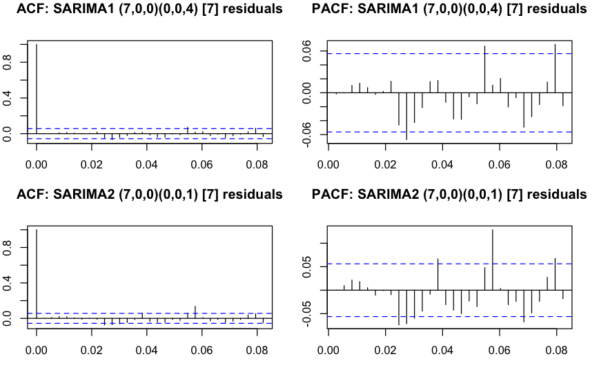

```r
par(mfrow=c(3,2) , mar = c(3, 2, 3, 2))
```

```r
acf(ar6_d1$residuals, na.action=na.pass, main = "ACF: AR (6,1,0) residuals")
pacf(ar6_d1$residuals, na.action=na.pass, main = "PACF: AR (6,1,0) residuals")
```

```r
acf(ar6_ma1_d1$residuals, na.action=na.pass, main = "ACF: ARMA (6,1,1) residuals")
pacf(ar6_ma1_d1$residuals, na.action=na.pass, main = "PACF: ARMA (6,1,1) residuals")
```

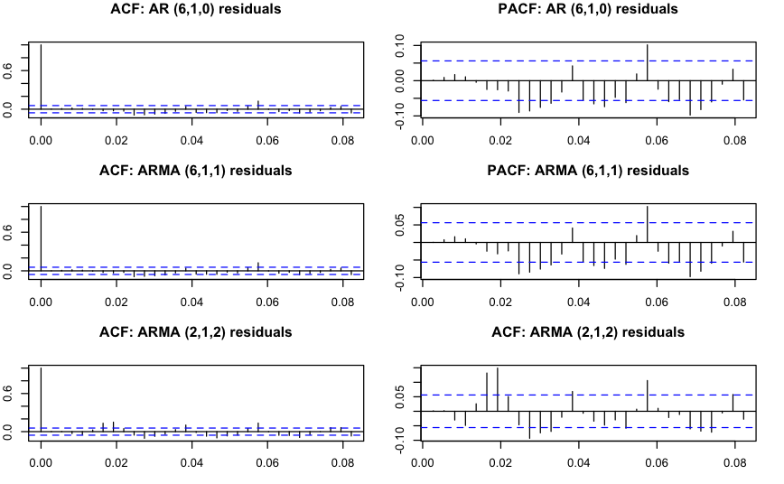

```r
acf(ar2_ma2_d1$residuals, na.action=na.pass, main = "ACF: ARMA (2,1,2) residuals")
pacf(ar2_ma2_d1$residuals, na.action=na.pass, main = "ACF: ARMA (2,1,2) residuals")
```

## 6. Multistep Forecast (In Sample)

The top 5 models have still some residuals that can be still removed. However all Pass the Box Ljung Test for white noise

```r
n = 7

# Sarima (7,0,0)(0,0,4)[7] (sarima1)
forecast1 <- forecast(sarima_ar7_ma4, h = n)
forecast1
```

|  | Point Forecast | Lo 80 | Hi 80 | Lo 95 | Hi 95 |
| --- | --- | --- | --- | --- | --- |
| 2023.3315 | 3.220131 | 2.708243 | 3.732018 | 2.437267 | 4.002995 |
| 2023.3342 | 3.137978 | 2.557916 | 3.718039 | 2.250850 | 4.025105 |
| 2023.3370 | 3.166810 | 2.551108 | 3.782513 | 2.225174 | 4.108446 |
| 2023.3397 | 3.275171 | 2.646747 | 3.903595 | 2.314080 | 4.236262 |
| 2023.3425 | 3.279635 | 2.642372 | 3.916898 | 2.305025 | 4.254244 |
| 2023.3452 | 3.233913 | 2.588029 | 3.879798 | 2.246118 | 4.221709 |
| 2023.3479 | 3.198438 | 2.529807 | 3.867070 | 2.175855 | 4.221022 |

```r
plot(forecast1, main = "DELIVERIES - Forecast (SARIMA (7,0,0)(0,0,4)[7])",include=150)
lines(fitted(sarima_ar7_ma4),col="red")
```

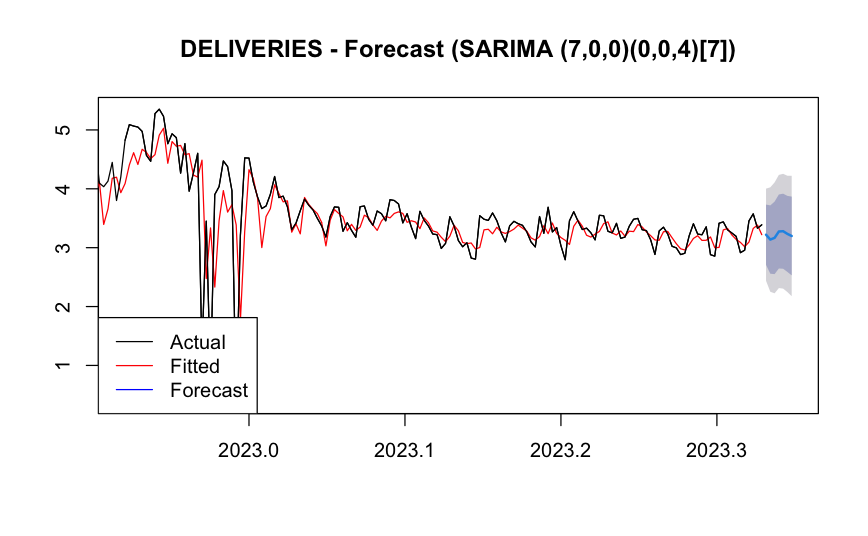

```r
lines(DATA) #plot the original series
legend("bottomleft", legend=c("Actual", "Fitted","Forecast"), lty=c(1,1,1), col=c( "black","red", "blue"))
```

```r
# Sarima (7,0,0)(0,0,1)[7] (sarima2)
forecast2 <- forecast(sarima_ar7_ma1, h = n)
forecast2
```

|  | Point Forecast | Lo 80 | Hi 80 | Lo 95 | Hi 95 |
| --- | --- | --- | --- | --- | --- |
| 2023.3315 | 3.216448 | 2.698775 | 3.734120 | 2.424736 | 4.008160 |
| 2023.3342 | 3.159976 | 2.571117 | 3.748835 | 2.259393 | 4.060558 |
| 2023.3370 | 3.197839 | 2.575296 | 3.820381 | 2.245742 | 4.149935 |
| 2023.3397 | 3.257812 | 2.624534 | 3.891091 | 2.289296 | 4.226328 |
| 2023.3425 | 3.255143 | 2.615602 | 3.894684 | 2.277050 | 4.233237 |
| 2023.3452 | 3.243644 | 2.598180 | 3.889109 | 2.256492 | 4.230797 |
| 2023.3479 | 3.207495 | 2.541753 | 3.873237 | 2.189331 | 4.225660 |

```r
plot(forecast2, main = "DELIVERIES - Forecast (SARIMA (7,0,0)(0,0,1)[7])",include=150)
lines(fitted(sarima_ar7_ma1),col="red")
```

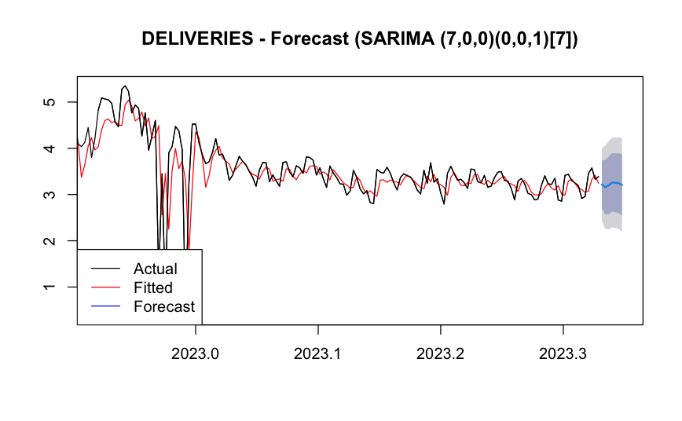

```r
lines(DATA) #plot the original series
legend("bottomleft", legend=c("Actual", "Fitted","Forecast"), lty=c(1,1,1), col=c( "black","red", "blue"))
```

```r
# ARMA (6,1,0) (ar6_d1)
forecast3 <- forecast(ar6_d1, h = n)
forecast3
```

|  | Point Forecast | Lo 80 | Hi 80 | Lo 95 | Hi 95 |
| --- | --- | --- | --- | --- | --- |
| 2023.3315 | 3.251675 | 2.729774 | 3.773575 | 2.453497 | 4.049853 |
| 2023.3342 | 3.212736 | 2.614769 | 3.810703 | 2.298224 | 4.127248 |
| 2023.3370 | 3.266101 | 2.629367 | 3.902834 | 2.292301 | 4.239900 |
| 2023.3397 | 3.341106 | 2.689563 | 3.992650 | 2.344656 | 4.337556 |
| 2023.3425 | 3.349943 | 2.688120 | 4.011766 | 2.337772 | 4.362114 |
| 2023.3452 | 3.344845 | 2.672504 | 4.017187 | 2.316588 | 4.373103 |
| 2023.3479 | 3.319564 | 2.618240 | 4.020887 | 2.246981 | 4.392146 |

```r
plot(forecast3, main = "DELIVERIES - Forecast (AR (6, 1, 0))", include=150)
lines(fitted(ar6_d1),col="red")
```

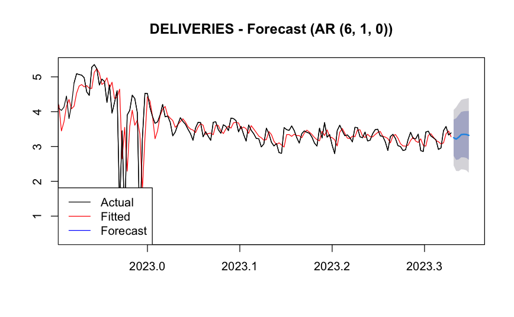

```r
lines(DATA) #plot the original series
legend("bottomleft", legend=c("Actual", "Fitted","Forecast"), lty=c(1,1,1), col=c( "black","red", "blue"))
```

```r
# ARMA (6,1,1) (ar6_ma1_d1)
forecast4 <- forecast(ar6_ma1_d1, h = n)
forecast4
```

|  | Point Forecast | Lo 80 | Hi 80 | Lo 95 | Hi 95 |
| --- | --- | --- | --- | --- | --- |
| 2023.3315 | 3.251721 | 2.729872 | 3.773569 | 2.453623 | 4.049819 |
| 2023.3342 | 3.211546 | 2.613525 | 3.809567 | 2.296952 | 4.126140 |
| 2023.3370 | 3.266859 | 2.629730 | 3.903988 | 2.292454 | 4.241264 |
| 2023.3397 | 3.345006 | 2.692807 | 3.997205 | 2.347553 | 4.342458 |
| 2023.3425 | 3.351918 | 2.689188 | 4.014648 | 2.338360 | 4.365476 |
| 2023.3452 | 3.344236 | 2.670796 | 4.017675 | 2.314299 | 4.374172 |
| 2023.3479 | 3.319902 | 2.617156 | 4.022648 | 2.245144 | 4.394660 |

```r
plot(forecast4, main = "DELIVERIES - Forecast (ARMA (6, 1, 1))", include=150)
lines(fitted(ar6_ma1_d1),col="red")
```

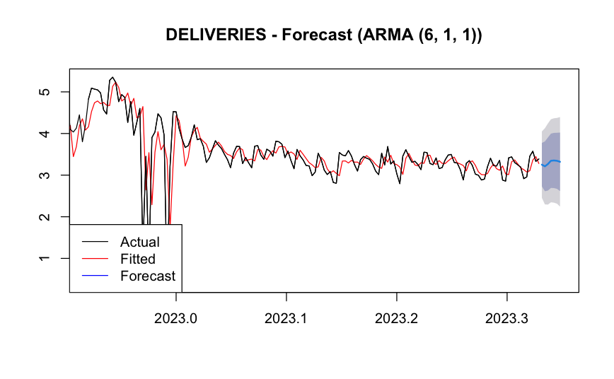

```r
lines(DATA) #plot the original series
legend("bottomleft", legend=c("Actual", "Fitted","Forecast"), lty=c(1,1,1), col=c( "black","red", "blue"))
```

```r
# ARMA (2,1,2) (ar2_ma2_d1)
forecast5 <- forecast(ar2_ma2_d1, h = n)
forecast5
```

|  | Point Forecast | Lo 80 | Hi 80 | Lo 95 | Hi 95 |
| --- | --- | --- | --- | --- | --- |
| 2023.3315 | 3.321163 | 2.795722 | 3.846603 | 2.517571 | 4.124755 |
| 2023.3342 | 3.297673 | 2.696433 | 3.898913 | 2.378156 | 4.217190 |
| 2023.3370 | 3.273527 | 2.639123 | 3.907930 | 2.303291 | 4.243762 |
| 2023.3397 | 3.270162 | 2.624278 | 3.916046 | 2.282367 | 4.257956 |
| 2023.3425 | 3.259864 | 2.605528 | 3.914199 | 2.259143 | 4.260584 |
| 2023.3452 | 3.261562 | 2.603295 | 3.919828 | 2.254830 | 4.268293 |
| 2023.3479 | 3.256171 | 2.593689 | 3.918653 | 2.242992 | 4.269350 |

```r
plot(forecast5, main = "DELIVERIES - Forecast (ARMA (2, 1, 2))", include=150)
lines(fitted(ar2_ma2_d1),col="red")
```

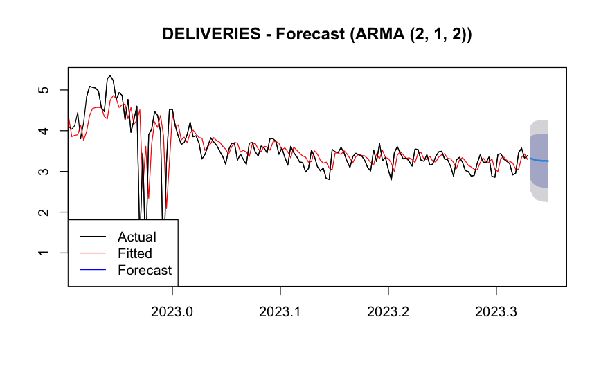

```r
lines(DATA) #plot the original series
legend("bottomleft", legend=c("Actual", "Fitted","Forecast"), lty=c(1,1,1), col=c( "black","red", "blue"))
```

## 7. Out-of Sample Analysis - Optimality of the forecast

The following Models are analyzed using out-of sample techniques Model 1: sarima_ar7_ma4 - SARIMA (7,0,0)(0,0,4)[7] Model 2: sarima_ar7_ma1 - SARIMA (7,0,0)(0,0,1)[7] Model 3: ar6_d1 - ARMA(6,1,0) Model 4: ar6_ma1_d1 - ARMA(6,1,1) Model 5: ar2_ma2_d1 - ARMA(2,1,2)

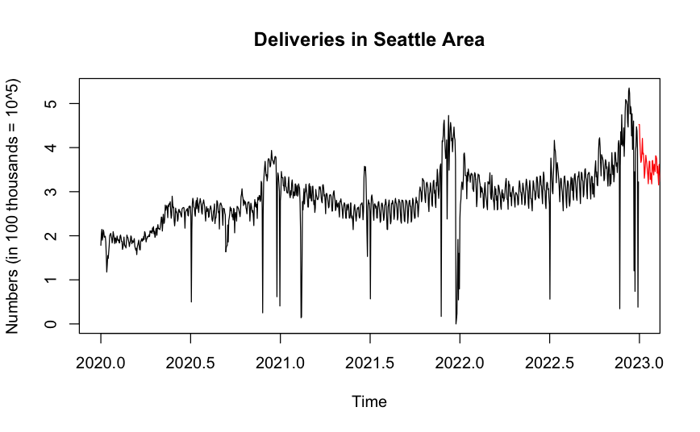

```r
prediction_size <- round(length(DATA)*0.10,0)
# hardcode
#prediction_size<- 21

split <- ts_split(ts.obj = DATA, sample.out = prediction_size)
es <- split$train
ps <- split$test
plot(es, ylab="Numbers (in 100 thousands = 10^5)", main = "Deliveries in Seattle Area")
lines(ps,col = "red")
```

```r
estimation_size <- length(es)
prediction_size
```

```
[1] 122
```

```r
estimation_size
```

```
[1] 1094
```

We will do the Forecast Optimal Test for the top 5 models from the previous in-sample analysis

```r
# Model 1 SARIMA (7,0,0)(0,0,4)[7]
fcast1<-numeric(prediction_size)
ferror1<-numeric(prediction_size)
loss1<-numeric(prediction_size)

for (i in  1: prediction_size) {
refit_model1 <- Arima(DELIVERIES[1:estimation_size + i], model=sarima_ar7_ma4)
fcast1[i]<-forecast(refit_model1, h=1)$mean
ferror1[i] <- ps[i] - fcast1[i]
loss1[i] <- ferror1[i]^2
}

mpetest1 <- lm(ferror1 ~ 1)
summary(mpetest1)
```

```
Call:
lm(formula = ferror1 ~ 1)

Residuals:
     Min       1Q   Median       3Q      Max
-0.34613 -0.08428  0.01848  0.08333  0.80086

Coefficients:
            Estimate Std. Error t value Pr(>|t|)
(Intercept)  0.05941    0.01384   4.293 3.57e-05 ***
---
Signif. codes:  0 ‘***’ 0.001 ‘**’ 0.01 ‘*’ 0.05 ‘.’ 0.1 ‘ ’ 1

Residual standard error: 0.1528 on 121 degrees of freedom
```

```r
IETest1 <- lm(ferror1 ~ fcast1)
summary(IETest1)
```

```
Call:
lm(formula = ferror1 ~ fcast1)

Residuals:
     Min       1Q   Median       3Q      Max
-0.36288 -0.06838  0.01643  0.07250  0.84222

Coefficients:
            Estimate Std. Error t value Pr(>|t|)
(Intercept) -0.35767    0.18885  -1.894   0.0606 .
fcast1       0.12517    0.05653   2.214   0.0287 *
---
Signif. codes:  0 ‘***’ 0.001 ‘**’ 0.01 ‘*’ 0.05 ‘.’ 0.1 ‘ ’ 1

Residual standard error: 0.1504 on 120 degrees of freedom
Multiple R-squared:  0.03926,   Adjusted R-squared:  0.03125
F-statistic: 4.903 on 1 and 120 DF,  p-value: 0.0287
```

```r
# Model 2 SARIMA (7,0,0)(0,0,1)[7]
fcast2<-numeric(prediction_size)
ferror2<-numeric(prediction_size)
loss2<-numeric(prediction_size)

for (i in  1: prediction_size) {
refit_model2 <- Arima(DELIVERIES[1:estimation_size + i], model=sarima_ar7_ma1)
fcast2[i]<-forecast(refit_model2, h=1)$mean
ferror2[i] <- ps[i] - fcast2[i]
loss2[i] <- ferror2[i]^2
}

mpetest2 <- lm(ferror2 ~ 1)
summary(mpetest1)
```

```
Call:
lm(formula = ferror1 ~ 1)

Residuals:
     Min       1Q   Median       3Q      Max
-0.34613 -0.08428  0.01848  0.08333  0.80086

Coefficients:
            Estimate Std. Error t value Pr(>|t|)
(Intercept)  0.05941    0.01384   4.293 3.57e-05 ***
---
Signif. codes:  0 ‘***’ 0.001 ‘**’ 0.01 ‘*’ 0.05 ‘.’ 0.1 ‘ ’ 1

Residual standard error: 0.1528 on 121 degrees of freedom
```

```r
IETest2 <- lm(ferror2 ~ fcast2)
summary(IETest2)
```

```
Call:
lm(formula = ferror2 ~ fcast2)

Residuals:
     Min       1Q   Median       3Q      Max
-0.23947 -0.07914  0.00429  0.06442  0.69315

Coefficients:
            Estimate Std. Error t value Pr(>|t|)
(Intercept)  -0.6084     0.1532  -3.972 0.000122 ***
fcast2        0.1964     0.0457   4.298 3.53e-05 ***
---
Signif. codes:  0 ‘***’ 0.001 ‘**’ 0.01 ‘*’ 0.05 ‘.’ 0.1 ‘ ’ 1

Residual standard error: 0.1204 on 120 degrees of freedom
Multiple R-squared:  0.1334,    Adjusted R-squared:  0.1262
F-statistic: 18.47 on 1 and 120 DF,  p-value: 3.532e-05
```

```r
# Model 3 - ARMA (6,1,0)
fcast3<-numeric(prediction_size)
ferror3<-numeric(prediction_size)
loss3<-numeric(prediction_size)

for (i in  1: prediction_size) {
refit_model3 <- Arima(DELIVERIES[1:estimation_size + i], model=ar6_d1)
fcast3[i]<-forecast(refit_model3, h=1)$mean
ferror3[i] <- ps[i] - fcast3[i]
loss3[i] <- ferror3[i]^2
}

mpetest3 <- lm(ferror3 ~ 1)
summary(mpetest3)
```

```
Call:
lm(formula = ferror3 ~ 1)

Residuals:
     Min       1Q   Median       3Q      Max
-0.24639 -0.08891  0.00807  0.07432  0.63891

Coefficients:
            Estimate Std. Error t value Pr(>|t|)
(Intercept) 0.001267   0.011520    0.11    0.913

Residual standard error: 0.1272 on 121 degrees of freedom
```

```r
IETest3 <- lm(ferror3 ~ fcast3)
summary(IETest3)
```

```
Call:
lm(formula = ferror3 ~ fcast3)

Residuals:
     Min       1Q   Median       3Q      Max
-0.26466 -0.08640  0.00292  0.07425  0.65814

Coefficients:
            Estimate Std. Error t value Pr(>|t|)
(Intercept)  -0.3858     0.1503  -2.567   0.0115 *
fcast3        0.1142     0.0442   2.583   0.0110 *
---
Signif. codes:  0 ‘***’ 0.001 ‘**’ 0.01 ‘*’ 0.05 ‘.’ 0.1 ‘ ’ 1

Residual standard error: 0.1244 on 120 degrees of freedom
Multiple R-squared:  0.05266,   Adjusted R-squared:  0.04477
F-statistic: 6.671 on 1 and 120 DF,  p-value: 0.011
```

```r
# Model 4 - ARMA (6,1,1)
fcast4<-numeric(prediction_size)
ferror4<-numeric(prediction_size)
loss4<-numeric(prediction_size)

for (i in  1: prediction_size) {
refit_model4 <- Arima(DELIVERIES[1:estimation_size + i], model=ar6_ma1_d1)
fcast4[i]<-forecast(refit_model4, h=1)$mean
ferror4[i] <- ps[i] - fcast4[i]
loss4[i] <- ferror4[i]^2
}

mpetest4 <- lm(ferror4 ~ 1)
summary(mpetest4)
```

```
Call:
lm(formula = ferror4 ~ 1)

Residuals:
     Min       1Q   Median       3Q      Max
-0.24682 -0.09049  0.00633  0.07452  0.64283

Coefficients:
            Estimate Std. Error t value Pr(>|t|)
(Intercept) 0.001368   0.011654   0.117    0.907

Residual standard error: 0.1287 on 121 degrees of freedom
```

```r
IETest4 <- lm(ferror4 ~ fcast4)
summary(IETest4)
```

```
Call:
lm(formula = ferror4 ~ fcast4)

Residuals:
     Min       1Q   Median       3Q      Max
-0.26457 -0.08942  0.00300  0.07563  0.66191

Coefficients:
            Estimate Std. Error t value Pr(>|t|)
(Intercept) -0.37381    0.15228  -2.455   0.0155 *
fcast4       0.11066    0.04479   2.471   0.0149 *
---
Signif. codes:  0 ‘***’ 0.001 ‘**’ 0.01 ‘*’ 0.05 ‘.’ 0.1 ‘ ’ 1

Residual standard error: 0.1261 on 120 degrees of freedom
Multiple R-squared:  0.04841,   Adjusted R-squared:  0.04048
F-statistic: 6.104 on 1 and 120 DF,  p-value: 0.01489
```

```r
# Model 5 - ARMA (6,1,1)
fcast5<-numeric(prediction_size)
ferror5<-numeric(prediction_size)
loss5<-numeric(prediction_size)

for (i in  1: prediction_size) {
refit_model5 <- Arima(DELIVERIES[1:estimation_size + i], model= ar2_ma2_d1)
fcast5[i]<-forecast(refit_model5, h=1)$mean
ferror5[i] <- ps[i] - fcast5[i]
loss5[i] <- ferror5[i]^2
}

mpetest5 <- lm(ferror5 ~ 1)
summary(mpetest5)
```

```
Call:
lm(formula = ferror5 ~ 1)

Residuals:
     Min       1Q   Median       3Q      Max
-0.22166 -0.08300  0.01196  0.06844  0.46088

Coefficients:
             Estimate Std. Error t value Pr(>|t|)
(Intercept) -0.038373   0.009767  -3.929 0.000143 ***
---
Signif. codes:  0 ‘***’ 0.001 ‘**’ 0.01 ‘*’ 0.05 ‘.’ 0.1 ‘ ’ 1

Residual standard error: 0.1079 on 121 degrees of freedom
```

```r
IETest5 <- lm(ferror5 ~ fcast5)
summary(IETest5)
```

```
Call:
lm(formula = ferror5 ~ fcast5)

Residuals:
     Min       1Q   Median       3Q      Max
-0.21609 -0.07043 -0.00040  0.06494  0.33578

Coefficients:
            Estimate Std. Error t value Pr(>|t|)
(Intercept) -0.67944    0.12294  -5.527 1.93e-07 ***
fcast5       0.18690    0.03575   5.228 7.34e-07 ***
---
Signif. codes:  0 ‘***’ 0.001 ‘**’ 0.01 ‘*’ 0.05 ‘.’ 0.1 ‘ ’ 1

Residual standard error: 0.09777 on 120 degrees of freedom
Multiple R-squared:  0.1855,    Adjusted R-squared:  0.1787
F-statistic: 27.33 on 1 and 120 DF,  p-value: 7.34e-07
```

```r
#Naive Model
fcast_naive<-numeric(prediction_size)
ferror_naive<-numeric(prediction_size)
loss_naive<-numeric(prediction_size)
start_index = length(DELIVERIES) - prediction_size

for (i in 1:prediction_size){
  fcast_naive[i]<-DELIVERIES[start_index -1 + i]
  ferror_naive[i]<-DELIVERIES[start_index+i]- fcast_naive[i]
  loss_naive[i] <-ferror_naive[i]^2
 }

mpetest_naive <- lm(ferror_naive ~ 1)
summary(mpetest_naive)
```

```
Call:
lm(formula = ferror_naive ~ 1)

Residuals:
     Min       1Q   Median       3Q      Max
-0.47463 -0.16075 -0.03533  0.11812  1.30226

Coefficients:
            Estimate Std. Error t value Pr(>|t|)
(Intercept)  0.00137    0.02400   0.057    0.955

Residual standard error: 0.2651 on 121 degrees of freedom
```

```r
IETest_naive <- lm(ferror_naive ~ fcast_naive)
summary(IETest_naive)
```

```
Call:
lm(formula = ferror_naive ~ fcast_naive)

Residuals:
     Min       1Q   Median       3Q      Max
-0.48765 -0.16332 -0.05345  0.12052  1.24066

Coefficients:
            Estimate Std. Error t value Pr(>|t|)
(Intercept)  1.23671    0.23942   5.165 9.67e-07 ***
fcast_naive -0.36438    0.07033  -5.181 9.02e-07 ***
---
Signif. codes:  0 ‘***’ 0.001 ‘**’ 0.01 ‘*’ 0.05 ‘.’ 0.1 ‘ ’ 1

Residual standard error: 0.2407 on 120 degrees of freedom
Multiple R-squared:  0.1828,    Adjusted R-squared:  0.176
F-statistic: 26.84 on 1 and 120 DF,  p-value: 9.021e-07
```

```r
#Average Model - taking average of last 4 observations
fcast_avg<-numeric(prediction_size)
ferror_avg<-numeric(prediction_size)
loss_avg<-numeric(prediction_size)
start_index = length(DELIVERIES) - prediction_size

for (i in 1:prediction_size){
  fcast_avg[i]<-(DELIVERIES[start_index -1 + i] + DELIVERIES[start_index -2 + i]  + DELIVERIES[start_index -3 + i] + DELIVERIES[start_index -4 + i])/4

  ferror_avg[i]<-DELIVERIES[start_index+i]- fcast_avg[i]
  loss_avg[i] <-ferror_avg[i]^2
 }

mpetest_avg <- lm(ferror_avg ~ 1)
summary(mpetest_avg)
```

```
Call:
lm(formula = ferror_avg ~ 1)

Residuals:
    Min      1Q  Median      3Q     Max
-0.6180 -0.2278 -0.0366  0.1843  1.5212

Coefficients:
            Estimate Std. Error t value Pr(>|t|)
(Intercept)  0.01598    0.03008   0.531    0.596

Residual standard error: 0.3322 on 121 degrees of freedom
```

```r
IETest_avg <- lm(ferror_avg ~ fcast_avg)
summary(IETest_avg)
```

```
Call:
lm(formula = ferror_avg ~ fcast_avg)

Residuals:
     Min       1Q   Median       3Q      Max
-0.58030 -0.18203 -0.01527  0.16015  1.28180

Coefficients:
            Estimate Std. Error t value Pr(>|t|)
(Intercept)   2.0989     0.3774   5.562 1.65e-07 ***
fcast_avg    -0.6170     0.1115  -5.534 1.87e-07 ***
---
Signif. codes:  0 ‘***’ 0.001 ‘**’ 0.01 ‘*’ 0.05 ‘.’ 0.1 ‘ ’ 1

Residual standard error: 0.2977 on 120 degrees of freedom
Multiple R-squared:  0.2033,    Adjusted R-squared:  0.1967
F-statistic: 30.62 on 1 and 120 DF,  p-value: 1.871e-07
```

# 8. Out of Sample Analysis - Test of Preditive ability

```r
cat("Model 1: \n")
```

```
Model 1:
```

```r
accuracy(fcast1, ps)
```

```
                 ME      RMSE       MAE      MPE     MAPE      ACF1 Theil's U
Test set 0.05941091 0.1634045 0.1264254 1.499267 3.675692 0.1540256 0.6229657
```

```r
MSE1 <- mean(loss1)
cat("MSE: ", MSE1)
```

```
MSE:  0.02670103
```

```r
cat("\n\nModel 2: \n")
```

```
Model 2:
```

```r
accuracy(fcast2, ps)
```

```
                 ME      RMSE       MAE     MPE     MAPE      ACF1 Theil's U
Test set 0.04820287 0.1370673 0.1071776 1.19126 3.120265 0.3943782  0.523953
```

```r
MSE2 <- mean(loss2)
cat("MSE: ", MSE2)
```

```
MSE:  0.01878746
```

```r
cat("\n\nModel 3: \n")
```

```
Model 3:
```

```r
accuracy(fcast3, ps)
```

```
                  ME      RMSE        MAE        MPE     MAPE      ACF1 Theil's U
Test set 0.001266935 0.1267247 0.09687102 -0.1688755 2.883118 0.3941343 0.4953236
```

```r
MSE3 <- mean(loss3)
cat("MSE: ", MSE3)
```

```
MSE:  0.01605916
```

```r
cat("\n\nModel 4: \n")
```

```
Model 4:
```

```r
accuracy(fcast4, ps)
```

```
                  ME      RMSE        MAE        MPE     MAPE      ACF1 Theil's U
Test set 0.001367634 0.1282008 0.09796088 -0.1673004 2.914466 0.3890202 0.5009669
```

```r
MSE4 <- mean(loss4)
cat("MSE: ", MSE4)
```

```
MSE:  0.01643544
```

```r
cat("\n\nModel 5: \n")
```

```
Model 5:
```

```r
accuracy(fcast5, ps)
```

```
                  ME      RMSE        MAE       MPE   MAPE      ACF1 Theil's U
Test set -0.03837299 0.1140877 0.08870377 -1.336391 2.6858 0.3355575 0.4581323
```

```r
MSE5 <- mean(loss5)
cat("MSE: ", MSE5)
```

```
MSE:  0.013016
```

```r
cat("\n\nNaive Model: \n")
```

```
Naive Model:
```

```r
accuracy(fcast_naive, ps)
```

```
                  ME      RMSE       MAE        MPE     MAPE        ACF1 Theil's U
Test set 0.001369918 0.2640614 0.1928634 -0.2490005 5.621549 -0.08383101         1
```

```r
MSE_naive <- mean(loss_naive)
cat("MSE: ", MSE_naive)
```

```
MSE:  0.06972841
```

```r
cat("\n\n4 period average Model: \n")
```

```
4 period average Model:
```

```r
accuracy(fcast_avg, ps)
```

```
                 ME     RMSE       MAE        MPE     MAPE      ACF1 Theil's U
Test set 0.01598162 0.331212 0.2437092 -0.1190842 7.071301 0.4976122  1.154406
```

```r
MSE_avg <- mean(loss_avg)
cat("MSE: ", MSE_avg)
```

```
MSE:  0.1097014
```

Notes: The lowest MSE are from model3 , model4 and model5 therefore we will use these models for creating the combination models.

## 9. Out of Sample Analysis - Combination Models

#### 9.1 Combination Model using equal weighted forecast

```r
combo1 <- (fcast3 + fcast4 + fcast5)/3
ferror_combo1 <- ps - combo1
loss_combo1 <- ferror_combo1^2

MSE_combo1 <- mean(loss_combo1)
MSE_combo1
```

```
[1] 0.01310528
```

```r
mpetest_combo1 <- lm(ferror_combo1 ~ 1)
summary(mpetest_combo1)
```

```
Call:
lm(formula = ferror_combo1 ~ 1)

Residuals:
     Min       1Q   Median       3Q      Max
-0.22182 -0.08219  0.01123  0.07897  0.46931

Coefficients:
            Estimate Std. Error t value Pr(>|t|)
(Intercept) -0.01191    0.01035  -1.151    0.252

Residual standard error: 0.1143 on 121 degrees of freedom
```

```r
IETest_combo1 <- lm(ferror_combo1 ~ combo1)
summary(IETest_combo1)
```

```
Call:
lm(formula = ferror_combo1 ~ combo1)

Residuals:
     Min       1Q   Median       3Q      Max
-0.24453 -0.06867 -0.00168  0.07408  0.46912

Coefficients:
            Estimate Std. Error t value Pr(>|t|)
(Intercept) -0.58277    0.13252  -4.398 2.38e-05 ***
combo1       0.16773    0.03883   4.319 3.24e-05 ***
---
Signif. codes:  0 ‘***’ 0.001 ‘**’ 0.01 ‘*’ 0.05 ‘.’ 0.1 ‘ ’ 1

Residual standard error: 0.1068 on 120 degrees of freedom
Multiple R-squared:  0.1346,    Adjusted R-squared:  0.1273
F-statistic: 18.66 on 1 and 120 DF,  p-value: 3.243e-05
```

#### 9.2 Combination Model using inverse of MSE

```r
sumMSE_inv <- (1/MSE3) + (1/MSE4) + (1/MSE5)
w3 <- (1/MSE3)/sumMSE_inv
w3
```

```
[1] 0.3114385
```

```r
w4 <- (1/MSE4)/sumMSE_inv
w4
```

```
[1] 0.3043083
```

```r
w5 <- (1/MSE5)/sumMSE_inv
w5
```

```
[1] 0.3842533
```

```r
combo2 <- w3*fcast3 + w4*fcast4 + w5*fcast5

ferror_combo2 <- ps - combo2
loss_combo2 <- ferror_combo2^2
MSE1_combo2 <- mean(loss_combo2)
MSE1_combo2
```

```
[1] 0.01280656
```

```r
mpetest_combo2 <- lm(ferror_combo2 ~ 1)
summary(mpetest_combo2)
```

```
Call:
lm(formula = ferror_combo2 ~ 1)

Residuals:
     Min       1Q   Median       3Q      Max
-0.21998 -0.08124  0.00943  0.07816  0.44308

Coefficients:
            Estimate Std. Error t value Pr(>|t|)
(Intercept) -0.01393    0.01021  -1.365    0.175

Residual standard error: 0.1128 on 121 degrees of freedom
```

```r
IETest_combo2 <- lm(ferror_combo2 ~ combo2)
summary(IETest_combo2)
```

```
Call:
lm(formula = ferror_combo2 ~ combo2)

Residuals:
     Min       1Q   Median       3Q      Max
-0.24090 -0.06712  0.00127  0.07316  0.43834

Coefficients:
            Estimate Std. Error t value Pr(>|t|)
(Intercept)  -0.6057     0.1301  -4.656 8.41e-06 ***
combo2        0.1738     0.0381   4.561 1.24e-05 ***
---
Signif. codes:  0 ‘***’ 0.001 ‘**’ 0.01 ‘*’ 0.05 ‘.’ 0.1 ‘ ’ 1

Residual standard error: 0.1045 on 120 degrees of freedom
Multiple R-squared:  0.1477,    Adjusted R-squared:  0.1406
F-statistic:  20.8 on 1 and 120 DF,  p-value: 1.239e-05
```

#### 9.3 Combination Model using OLS weights

```r
combo3<-lm(ps~fcast3+fcast4+fcast5)
summary(combo3)
```

```
Call:
lm(formula = ps ~ fcast3 + fcast4 + fcast5)

Residuals:
     Min       1Q   Median       3Q      Max
-0.21115 -0.05908 -0.00427  0.06747  0.26231

Coefficients:
            Estimate Std. Error t value Pr(>|t|)
(Intercept)  -0.6762     0.1213  -5.574 1.60e-07 ***
fcast3        3.8382     2.8067   1.368    0.174
fcast4       -3.5130     2.7476  -1.279    0.204
fcast5        0.8644     0.1198   7.214 5.65e-11 ***
---
Signif. codes:  0 ‘***’ 0.001 ‘**’ 0.01 ‘*’ 0.05 ‘.’ 0.1 ‘ ’ 1

Residual standard error: 0.09541 on 118 degrees of freedom
Multiple R-squared:  0.9081,    Adjusted R-squared:  0.9057
F-statistic: 388.5 on 3 and 118 DF,  p-value: < 2.2e-16
```

```r
fcast_combo3<-predict(combo3)
ferror_combo3 <- ps - fcast_combo3
loss_combo3 <- ferror_combo3^2

mpetest_combo3 <- lm(ferror_combo3 ~ 1)
summary(mpetest_combo3)
```

```
Call:
lm(formula = ferror_combo3 ~ 1)

Residuals:
     Min       1Q   Median       3Q      Max
-0.21115 -0.05908 -0.00427  0.06747  0.26231

Coefficients:
              Estimate Std. Error t value Pr(>|t|)
(Intercept) -1.971e-15  8.531e-03       0        1

Residual standard error: 0.09422 on 121 degrees of freedom
```

```r
IETest_combo3 <- lm(ferror_combo3 ~ fcast_combo3)
summary(IETest_combo3)
```

```
Call:
lm(formula = ferror_combo3 ~ fcast_combo3)

Residuals:
     Min       1Q   Median       3Q      Max
-0.21115 -0.05908 -0.00427  0.06747  0.26231

Coefficients:
               Estimate Std. Error t value Pr(>|t|)
(Intercept)   1.357e-14  9.889e-02       0        1
fcast_combo3 -4.581e-15  2.905e-02       0        1

Residual standard error: 0.09462 on 120 degrees of freedom
Multiple R-squared:  2.023e-28, Adjusted R-squared:  -0.008333
F-statistic: 2.427e-26 on 1 and 120 DF,  p-value: 1
```

```r
MSE_combo3 <- mean(loss_combo3)
MSE_combo3
```

```
[1] 0.008805348
```

```r
#plot(combo3)
```

## 10. Out of Sample - Visualizing the best forecast - Combination Model 3 - OLS weighted

```r
#summary(combo3)
final_forecast <-ts(fcast_combo3,start = end(es),frequency = 365)

plot(ps, main = "DELIVERIES - OLS Weighted Optimal Forecast (1-step)",col="black",xlab ="Prediction Sample, Daily", ylab= "Number of Deliveries (in 10^5)")
lines(final_forecast,col="blue")
```

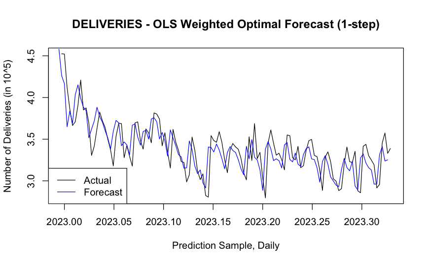

```r
legend("bottomleft", legend=c("Actual","Forecast"), lty=c(1,1,1), col=c( "black", "blue"))
```